# Final project

Minjie Bao (mb4757)

16 December, 2020

### Consider interactions between variables (e.g., urbanization), and if the case, fit stratified models.

Data summary

| Name | data_crimes |
| --- | --- |
| Number of rows | 51 |
| Number of columns | 9 |
| _______________________ |  |
| Column type frequency: |  |
| character | 1 |
| factor | 2 |
| numeric | 6 |
| ________________________ |  |
| Group variables | None |

**Variable type: character**

| skim_variable | n_missing | complete_rate | min | max | empty | n_unique | whitespace |
| --- | --- | --- | --- | --- | --- | --- | --- |
| state | 0 | 1 | 4 | 20 | 0 | 51 | 0 |

**Variable type: factor**

| skim_variable | n_missing | complete_rate | ordered | n_unique | top_counts |
| --- | --- | --- | --- | --- | --- |
| unemployment | 0 | 1 | FALSE | 2 | 0: 27, 1: 24 |
| urbanization | 0 | 1 | FALSE | 2 | 0: 27, 1: 24 |

**Variable type: numeric**

| skim_variable | n_missing | complete_rate | mean | sd | p0 | p25 | p50 | p75 | p100 | hist |
| --- | --- | --- | --- | --- | --- | --- | --- | --- | --- | --- |
| median_household_income | 0 | 1.00 | 55223.61 | 9208.48 | 35521.00 | 48657.00 | 54916.00 | 60719.00 | 76165.00 | ▂▆▇▅▂ |
| perc_population_with_high_school_degree | 0 | 1.00 | 0.87 | 0.03 | 0.80 | 0.84 | 0.87 | 0.90 | 0.92 | ▃▅▃▆▇ |
| perc_non_citizen | 3 | 0.94 | 0.05 | 0.03 | 0.01 | 0.03 | 0.04 | 0.08 | 0.13 | ▇▆▆▂▂ |
| gini_index | 0 | 1.00 | 0.45 | 0.02 | 0.42 | 0.44 | 0.45 | 0.47 | 0.53 | ▆▇▅▁▁ |
| perc_non_white | 0 | 1.00 | 0.32 | 0.16 | 0.06 | 0.20 | 0.28 | 0.42 | 0.81 | ▇▇▆▂▁ |
| hate_crimes_per_100k_splc | 4 | 0.92 | 0.30 | 0.25 | 0.07 | 0.14 | 0.23 | 0.36 | 1.52 | ▇▂▁▁▁ |

```
Call:
lm(formula = hate_crimes_per_100k_splc ~ unemployment + urbanization +
    median_household_income + perc_population_with_high_school_degree +
    perc_non_citizen + gini_index + perc_non_white, data = data_crimes)

Residuals:
     Min       1Q   Median       3Q      Max
-0.36552 -0.10314 -0.01316  0.09731  0.51389

Coefficients:
                                          Estimate Std. Error t value Pr(>|t|)
(Intercept)                             -8.296e+00  1.908e+00  -4.349 0.000103 ***
unemployment0                            1.307e-02  7.173e-02   0.182 0.856425
urbanization0                            3.309e-02  8.475e-02   0.390 0.698475
median_household_income                 -1.504e-06  5.961e-06  -0.252 0.802193
perc_population_with_high_school_degree  5.382e+00  1.835e+00   2.933 0.005735 **
perc_non_citizen                         1.233e+00  1.877e+00   0.657 0.515332
gini_index                               8.624e+00  1.973e+00   4.370 9.67e-05 ***
perc_non_white                          -5.842e-03  3.673e-01  -0.016 0.987396
---
Signif. codes:  0 '***' 0.001 '**' 0.01 '*' 0.05 '.' 0.1 ' ' 1

Residual standard error: 0.2014 on 37 degrees of freedom
  (6 observations deleted due to missingness)
Multiple R-squared:  0.461, Adjusted R-squared:  0.3591
F-statistic: 4.521 on 7 and 37 DF,  p-value: 0.001007
```

There are two significant variables: perc_population_with_high_school_degree and gini_index.

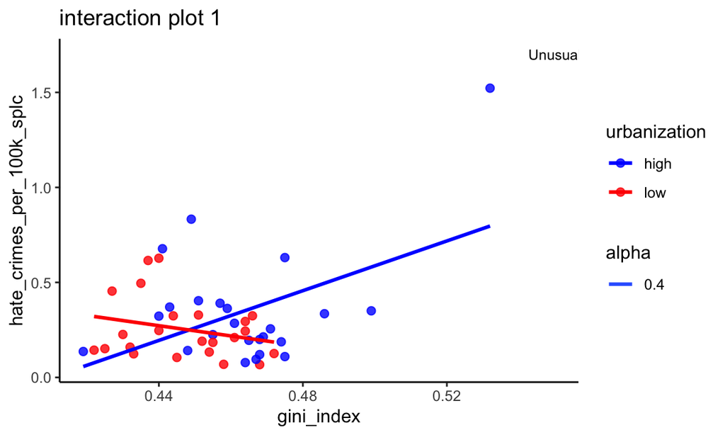

```
Call:
lm(formula = hate_crimes_per_100k_splc ~ gini_index * urbanization,
    data = data_crimes)

Residuals:
     Min       1Q   Median       3Q      Max
-0.31410 -0.16085 -0.04934  0.10459  0.72556

Coefficients:
                         Estimate Std. Error t value Pr(>|t|)
(Intercept)                -2.684      1.019  -2.635  0.01166 *
gini_index                  6.542      2.193   2.984  0.00468 **
urbanization0               4.142      1.779   2.329  0.02464 *
gini_index:urbanization0   -9.238      3.931  -2.350  0.02343 *
---
Signif. codes:  0 '***' 0.001 '**' 0.01 '*' 0.05 '.' 0.1 ' ' 1

Residual standard error: 0.2318 on 43 degrees of freedom
  (4 observations deleted due to missingness)
Multiple R-squared:  0.2134,    Adjusted R-squared:  0.1586
F-statistic: 3.889 on 3 and 43 DF,  p-value: 0.01518
```

```
Call:
lm(formula = hate_crimes_per_100k_splc ~ gini_index, data = high_urban)

Residuals:
    Min      1Q  Median      3Q     Max
-0.3141 -0.1910 -0.0866  0.1302  0.7256

Coefficients:
            Estimate Std. Error t value Pr(>|t|)
(Intercept)   -2.684      1.250  -2.148   0.0430 *
gini_index     6.542      2.690   2.432   0.0236 *
---
Signif. codes:  0 '***' 0.001 '**' 0.01 '*' 0.05 '.' 0.1 ' ' 1

Residual standard error: 0.2844 on 22 degrees of freedom
Multiple R-squared:  0.2119,    Adjusted R-squared:  0.1761
F-statistic: 5.914 on 1 and 22 DF,  p-value: 0.02361
```

```
Call:
lm(formula = hate_crimes_per_100k_splc ~ gini_index, data = low_urban)

Residuals:
     Min       1Q   Median       3Q      Max
-0.17719 -0.13198 -0.04745  0.08652  0.35508

Coefficients:
            Estimate Std. Error t value Pr(>|t|)
(Intercept)    1.459      1.001   1.458    0.160
gini_index    -2.696      2.239  -1.204    0.242

Residual standard error: 0.1591 on 21 degrees of freedom
  (4 observations deleted due to missingness)
Multiple R-squared:  0.06459,   Adjusted R-squared:  0.02004
F-statistic:  1.45 on 1 and 21 DF,  p-value: 0.2419
```

From the graph, two regression lines for each level category of urbanization interacts with each other. Also, from the model with the interaction term, the p value of the interaction term is 0.02343 < 0.05, so the interaction term is significant.

Since the interaction term is significant, we will do stratification:

For high urbanization, the estimated coefficient of gini_index is 6.542 > 0, which means that with one unit increase in gini_index, the estimated hate_crimes_per_100k_splc level will increase by 6.542 unit. The p value is 0.0236 < 0.05, which means at the significance level of 0.05, the estimated coefficient of gini_index is significantly different than 0.

For low urbanization, the estimated coefficient of gini_index is -2.696 < 0, which means that with one unit increase in gini_index, the estimated hate_crimes_per_100k_splc level will decrease by 2.696 unit. The p value is 0.242 > 0.05, which means at the significance level of 0.05, the estimated coefficient of gini_index is not significantly different than 0.

As we can see, the slopes of high and low urbanization have different directionality, which means the associations between gini_index and hate_crimes_per_100k_splc level have opposite directions for the two groups.

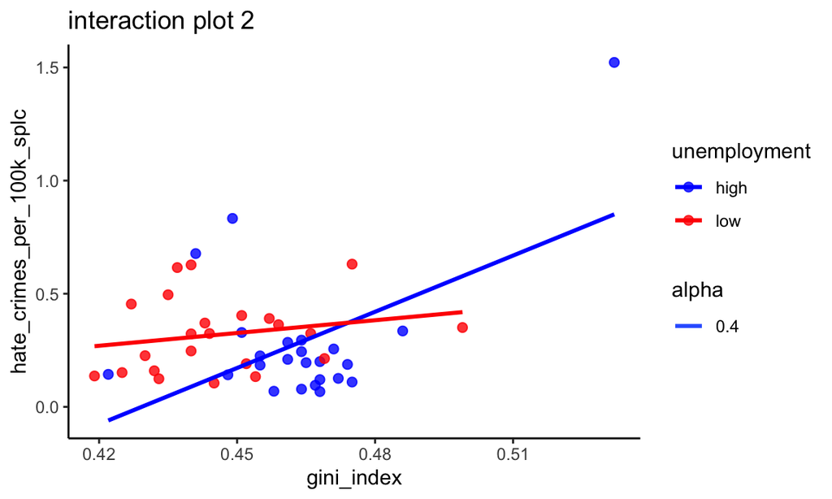

```
Call:
lm(formula = hate_crimes_per_100k_splc ~ gini_index * unemployment,
    data = data_crimes)

Residuals:
     Min       1Q   Median       3Q      Max
-0.26910 -0.14406 -0.05300  0.05402  0.67146

Coefficients:
                         Estimate Std. Error t value Pr(>|t|)
(Intercept)                -3.555      1.156  -3.075  0.00365 **
gini_index                  8.281      2.489   3.327  0.00180 **
unemployment0               3.035      1.665   1.823  0.07534 .
gini_index:unemployment0   -6.400      3.658  -1.750  0.08733 .
---
Signif. codes:  0 '***' 0.001 '**' 0.01 '*' 0.05 '.' 0.1 ' ' 1

Residual standard error: 0.2316 on 43 degrees of freedom
  (4 observations deleted due to missingness)
Multiple R-squared:  0.215, Adjusted R-squared:  0.1603
F-statistic: 3.926 on 3 and 43 DF,  p-value: 0.01457
```

Although the visualization above indicates that an interaction might exist, from the numeric summaries, the p-value of gini_index:unemployment0 is not significant(p-value = 0.08733 > 0.05). Therefore, there’s no evidence of interaction of gini_index and unemployment, which means the effect of gini_index on hate_crimes_per_100k_splc is not different with respect to the levels of unemployment.

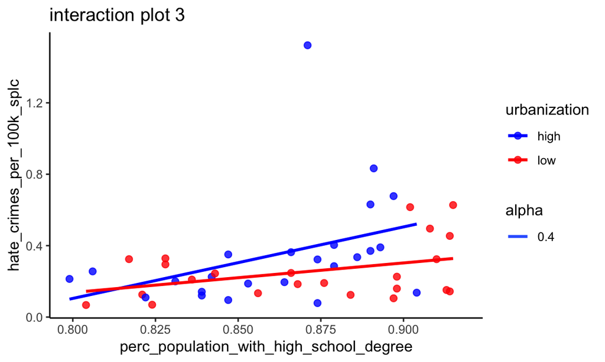

```
Call:
lm(formula = hate_crimes_per_100k_splc ~ perc_population_with_high_school_degree *
    urbanization, data = data_crimes)

Residuals:
     Min       1Q   Median       3Q      Max
-0.38440 -0.12402 -0.06568  0.11205  1.13354

Coefficients:
                                                      Estimate Std. Error t value Pr(>|t|)
(Intercept)                                             -3.100      1.464  -2.117   0.0401 *
perc_population_with_high_school_degree                  4.006      1.698   2.359   0.0229 *
urbanization0                                            1.913      1.870   1.023   0.3120
perc_population_with_high_school_degree:urbanization0   -2.350      2.160  -1.088   0.2828
---
Signif. codes:  0 '***' 0.001 '**' 0.01 '*' 0.05 '.' 0.1 ' ' 1

Residual standard error: 0.2375 on 43 degrees of freedom
  (4 observations deleted due to missingness)
Multiple R-squared:  0.1745,    Adjusted R-squared:  0.1169
F-statistic:  3.03 on 3 and 43 DF,  p-value: 0.03951
```

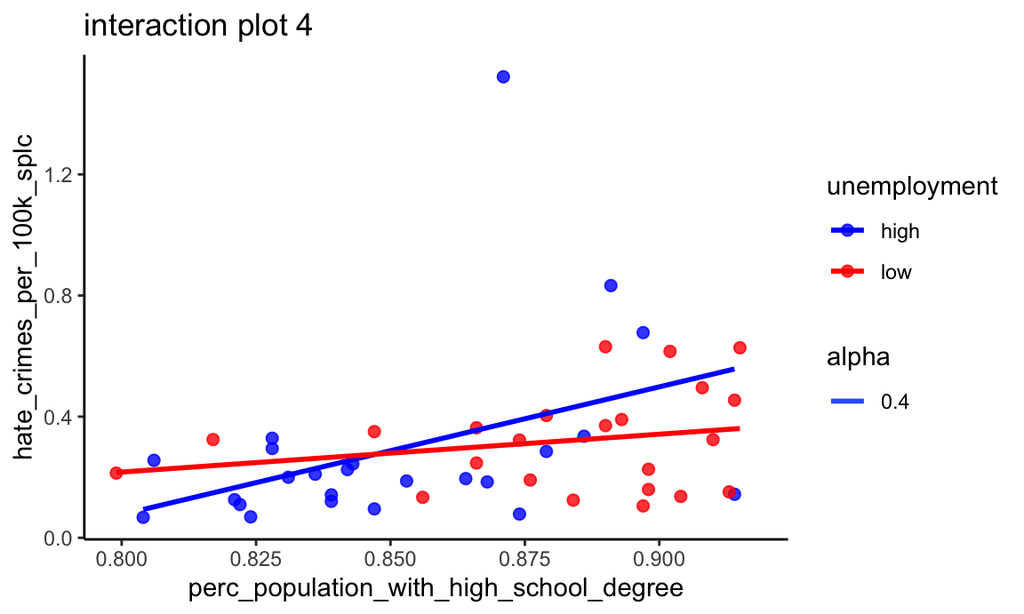

```
Call:
lm(formula = hate_crimes_per_100k_splc ~ perc_population_with_high_school_degree *
    unemployment, data = data_crimes)

Residuals:
     Min       1Q   Median       3Q      Max
-0.41372 -0.12303 -0.02848  0.08708  1.14619

Coefficients:
                                                      Estimate Std. Error t value Pr(>|t|)
(Intercept)                                             -3.297      1.466  -2.250   0.0296 *
perc_population_with_high_school_degree                  4.217      1.723   2.448   0.0185 *
unemployment0                                            2.514      2.109   1.192   0.2398
perc_population_with_high_school_degree:unemployment0   -2.967      2.432  -1.220   0.2292
---
Signif. codes:  0 '***' 0.001 '**' 0.01 '*' 0.05 '.' 0.1 ' ' 1

Residual standard error: 0.2431 on 43 degrees of freedom
  (4 observations deleted due to missingness)
Multiple R-squared:  0.1351,    Adjusted R-squared:  0.07479
F-statistic:  2.24 on 3 and 43 DF,  p-value: 0.0973
```

Although the visualization above indicates that an interaction might exist; however, from the numeric summaries, the p-value of perc_population_with_high_school_degree:unemployment0 is 0.2292 > 0.05 which is not significant. Therefore, there’s no evidence of interaction of perc_population_with_high_school_degree and unemployment, which means the effect of perc_population_with_high_school_degree on hate_crimes_per_100k_splc is not different with respect to the levels of unemployment.

Counfounder:

Condition 1)

```
Call:
lm(formula = hate_crimes_per_100k_splc ~ urbanization, data = data_crimes)

Residuals:
     Min       1Q   Median       3Q      Max
-0.27357 -0.14369 -0.06352  0.04624  1.17043

Coefficients:
              Estimate Std. Error t value Pr(>|t|)
(Intercept)    0.35187    0.05115   6.879 1.54e-08 ***
urbanization0 -0.09763    0.07312  -1.335    0.189
---
Signif. codes:  0 '***' 0.001 '**' 0.01 '*' 0.05 '.' 0.1 ' ' 1

Residual standard error: 0.2506 on 45 degrees of freedom
  (4 observations deleted due to missingness)
Multiple R-squared:  0.03811,   Adjusted R-squared:  0.01673
F-statistic: 1.783 on 1 and 45 DF,  p-value: 0.1885
```

```
Analysis of Variance Table

Response: hate_crimes_per_100k_splc
             Df  Sum Sq  Mean Sq F value Pr(>F)
urbanization  1 0.11195 0.111953  1.7829 0.1885
Residuals    45 2.82568 0.062793
```

urbanization not associated with the outcome

Condition 2)

```
Call:
lm(formula = gini_index ~ urbanization, data = data_crimes)

Residuals:
      Min        1Q    Median        3Q       Max
-0.045000 -0.012167 -0.000667  0.010167  0.068000

Coefficients:
               Estimate Std. Error t value Pr(>|t|)
(Intercept)    0.464000   0.003810 121.781  < 2e-16 ***
urbanization0 -0.019333   0.005237  -3.692 0.000559 ***
---
Signif. codes:  0 '***' 0.001 '**' 0.01 '*' 0.05 '.' 0.1 ' ' 1

Residual standard error: 0.01867 on 49 degrees of freedom
Multiple R-squared:  0.2176,    Adjusted R-squared:  0.2017
F-statistic: 13.63 on 1 and 49 DF,  p-value: 0.0005592
```

```
Analysis of Variance Table

Response: gini_index
             Df    Sum Sq   Mean Sq F value    Pr(>F)
urbanization  1 0.0047492 0.0047492  13.631 0.0005592 ***
Residuals    49 0.0170720 0.0003484
---
Signif. codes:  0 '***' 0.001 '**' 0.01 '*' 0.05 '.' 0.1 ' ' 1
```

urbanization associated with the exposure

```
Call:
lm(formula = hate_crimes_per_100k_splc ~ gini_index, data = data_crimes)

Residuals:
     Min       1Q   Median       3Q      Max
-0.28669 -0.14565 -0.04991  0.07356  0.91085

Coefficients:
            Estimate Std. Error t value Pr(>|t|)
(Intercept)  -1.5275     0.7833  -1.950   0.0574 .
gini_index    4.0205     1.7177   2.341   0.0237 *
---
Signif. codes:  0 '***' 0.001 '**' 0.01 '*' 0.05 '.' 0.1 ' ' 1

Residual standard error: 0.2412 on 45 degrees of freedom
  (4 observations deleted due to missingness)
Multiple R-squared:  0.1085,    Adjusted R-squared:  0.08872
F-statistic: 5.478 on 1 and 45 DF,  p-value: 0.02374
```

```
Call:
lm(formula = hate_crimes_per_100k_splc ~ gini_index + urbanization,
    data = data_crimes)

Residuals:
     Min       1Q   Median       3Q      Max
-0.28248 -0.14938 -0.05577  0.06162  0.92103

Coefficients:
              Estimate Std. Error t value Pr(>|t|)
(Intercept)   -1.34994    0.88817  -1.520   0.1357
gini_index     3.66771    1.91115   1.919   0.0615 .
urbanization0 -0.03433    0.07832  -0.438   0.6633
---
Signif. codes:  0 '***' 0.001 '**' 0.01 '*' 0.05 '.' 0.1 ' ' 1

Residual standard error: 0.2434 on 44 degrees of freedom
  (4 observations deleted due to missingness)
Multiple R-squared:  0.1124,    Adjusted R-squared:  0.07206
F-statistic: 2.786 on 2 and 44 DF,  p-value: 0.07256
```

```
Analysis of Variance Table

Response: hate_crimes_per_100k_splc
             Df  Sum Sq Mean Sq F value  Pr(>F)
gini_index    1 0.31882 0.31882  5.3801 0.02507 *
urbanization  1 0.01138 0.01138  0.1921 0.66333
Residuals    44 2.60743 0.05926
---
Signif. codes:  0 '***' 0.001 '**' 0.01 '*' 0.05 '.' 0.1 ' ' 1
```

for gini_index be on the causal path way it means gini_index impacts urbanization, urbanization impact hate_crimes_per_100k_splc, in this case gini_index not on the path way.

By adjusting to urbanization the coefficient of gini_index reduced by almost 9%. Therefore, urbanization does not confoud the relationship between gini_index and hate_crimes_per_100k_splc.

The gini_index coefficient reduced from 4.0205 in SLR to 3.66771 in MLR after adjusting for urbanization (~9% reduction).

We can conclude that urbanization not confounds the relationship b/w gini_index and hate_crimes_per_100k_splc.